# Unsupervised learning capstone

## Amazon reviews: a study

### A project analyzing product reviews focusing on clustering, visualization, and embedding

#### Data source:

This dataset is a large collection of Amazon reviews in text with the following information:

- Review ID: Unique identifier for review
- ProductID: Unique identifier for product
- UserID: Unique identifier for user
- ProfileName: Self-selected name for reviewer
- HelpfulnessRatings: Values on how helpful others found review
- Score: Ratings 1-5 given by reviewer on product
- Summary: Short title / summary of review
- Review: Full text review

### Capstone goals

#### Primary goals of the capstone are to mine through cleaned text reviews and:

1. Cluster reviews by author
2. Hypothesize as to reasons why

#### To complete the goals, there are several major steps:

1. Import data
2. Data and text cleaning
3. Text parsing
4. tf-idf fitting, unsupervised modeling, and clustering
5. gensim and word2vec, doc2vec
6. Applicable visualizations
7. Conclusions

The steps above are standard to my approach. Steps that are more ad hoc to this exercise are explained as they arise.

### Let's begin!

#### Starting points

We will start with imports:

- pandas
- numpy
- seaborn for dataviz
- spacy and gensim for text manipulation and embedding
- pickle, collections for Python fun
- sklearn for text tools, pipeline, decomposition, scaler, cluster algorithms

A dataframe of the reviews and some preliminary visualizations.

```python
# Various necessary imports
import numpy as np
import pandas as pd
import re
import sqlite3
import spacy
import matplotlib.pyplot as plt
import seaborn as sns
import pickle
from collections import Counter
from gensim.models import Word2Vec, Doc2Vec
from gensim.models.doc2vec import TaggedDocument
from sklearn.model_selection import train_test_split
from sklearn.feature_extraction.text import TfidfVectorizer
from sklearn.decomposition import TruncatedSVD
from sklearn.cluster import KMeans, MiniBatchKMeans, SpectralClustering, estimate_bandwidth, MeanShift
from sklearn.manifold import TSNE
from sklearn.pipeline import make_pipeline
from sklearn.preprocessing import Normalizer, StandardScaler
sns.set_style('darkgrid')
%matplotlib inline
nlp = spacy.load('en_core_web_sm')
```

```python
# If we want to work with a sqlite version, we have the option
# conn = sqlite3.connect('../../../amazon-fine-food-reviews/database.sqlite')
# c = conn.cursor()
# c.execute('SELECT * FROM reviews LIMIT 1;')
# c.fetchall()

df_orig = pd.read_csv('../../../amazon-fine-food-reviews/Reviews.csv')
df_orig.head(2)
```

|  | Id | ProductId | UserId | ProfileName | HelpfulnessNumerator | HelpfulnessDenominator | Score | Time | Summary | Text |
| --- | --- | --- | --- | --- | --- | --- | --- | --- | --- | --- |
| 0 | 1 | B001E4KFG0 | A3SGXH7AUHU8GW | delmartian | 1 | 1 | 5 | 1303862400 | Good Quality Dog Food | I have bought several of the Vitality canned d... |
| 1 | 2 | B00813GRG4 | A1D87F6ZCVE5NK | dll pa | 0 | 0 | 1 | 1346976000 | Not as Advertised | Product arrived labeled as Jumbo Salted Peanut... |

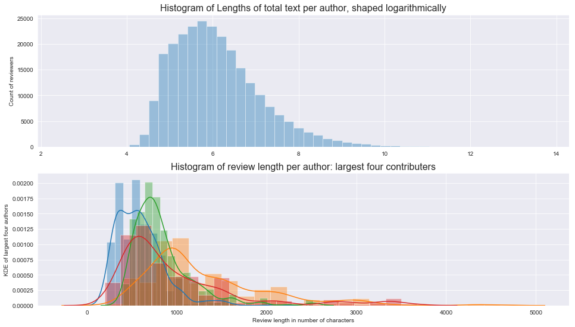

```python
fig, (ax1, ax2) = plt.subplots(2, 1, figsize=(16,9))

sns.distplot([np.log(len(summary)) for summary in df_orig.groupby(by='UserId')['Text'].sum()], kde=False, ax=ax1)
ax1.set_title('Histogram of Lengths of total text per author, shaped logarithmically', size=16)
ax1.set_ylabel('Count of reviewers')

for id in df_orig.UserId.value_counts()[:4].index:
    sns.distplot(df_orig[df_orig.UserId == id]['Text'].str.len(), ax=ax2)
ax2.set_title('Histogram of review length per author: largest four contributers', size=16)
ax2.set_ylabel('KDE of largest four authors')
ax2.set_xlabel('Review length in number of characters')
plt.show()
```

```python
# Test spacy, stop words, lemma_, etc.
doc = nlp(df_orig.iloc[0]['Text'])
[token.lemma_.lower() for token in doc if not token.is_punct and not token.is_stop][:6]
```

```
['-pron-', 'buy', 'vitality', 'can', 'dog', 'food']
```

```python
# To reduce the number of authors and attempt to classify, let's see how to reduce
df = df_orig[df_orig.UserId.isin(df_orig.UserId.value_counts()[:12].index)]
print('Length of total text of 12 highest-reviewing: {}.\n'.format(len(df['Text'].str.cat())))
print(df.UserId.value_counts())
```

```
Length of total text of 12 highest-reviewing: 4099187.

A3OXHLG6DIBRW8    448
A1YUL9PCJR3JTY    421
AY12DBB0U420B     389
A281NPSIMI1C2R    365
A1Z54EM24Y40LL    256
A1TMAVN4CEM8U8    204
A2MUGFV2TDQ47K    201
A3TVZM3ZIXG8YW    199
A3PJZ8TU8FDQ1K    178
AQQLWCMRNDFGI     176
A2SZLNSI5KOQJT    175
A29JUMRL1US6YP    172
Name: UserId, dtype: int64
```

## Word length max

Placing tokens and text into memory with spaCy has limits. We will need to keep the word length below one million for this exercise. Below we have a function that takes an index of reviewers and a number of reviews from each to balance samples to return total word length. This lets us know what we can use and expect. We loop this over several numbers to find a good balance of robust text that fits in memory.

```python
def how_long(index_len, long, df=df_orig, return_='n'):
    assert type(long) == int
    index_list = df.UserId.value_counts()[:index_len].index
    df_list = []
    sampled = False
    for index in index_list:
        if len(df[df.UserId == index]) > long:
            df_sample = df[df.UserId == index].sample(n=long)
        else:
            df_sample = df[df.UserId == index]
            sampled = True
        df_list.append(df_sample)
    df_new = pd.concat(df_list)
    print("The dataframe with {} samples from each reviewer is a total of {} words long.".
          format(long, len(df_new['Text'].str.cat())))
    if sampled:
        print("Class imbalance present.")
    if return_ == 'y':
        return df_new

for val in range(10, 100, 10):
    how_long(15, val)
```

```
The dataframe with 10 samples from each reviewer is a total of 182446 words long.
The dataframe with 20 samples from each reviewer is a total of 367873 words long.
The dataframe with 30 samples from each reviewer is a total of 546729 words long.
The dataframe with 40 samples from each reviewer is a total of 745140 words long.
The dataframe with 50 samples from each reviewer is a total of 912971 words long.
The dataframe with 60 samples from each reviewer is a total of 1097585 words long.
The dataframe with 70 samples from each reviewer is a total of 1290241 words long.
The dataframe with 80 samples from each reviewer is a total of 1446741 words long.
The dataframe with 90 samples from each reviewer is a total of 1622292 words long.
```

```python
df = how_long(15, 52, return_='y')
```

```
The dataframe with 52 samples from each reviewer is a total of 971617 words long.
```

## Samples from each reviewer: 52

Pulling 52 samples from each reviewer yields slightly fewer than one million words. This is the target.

## Reviewing the samples

After poking around the text and using regular expressions to clean up, I noticed some issues with duplication:

```python
kab_list = df[df.Text.str.contains('Kaboodle')].index[:2]
df[df.Text.str.contains('Kaboodle')]['Text'][kab_list[0]] == df[df.Text.str.contains('Kaboodle')]['Text'][kab_list[1]]
```

```
True
```

```python
for user in df_orig.UserId.value_counts()[:3].index:
    print(user, '  ', df_orig[df_orig.UserId == user]['Text'].duplicated().value_counts(), '\n')
```

```
A3OXHLG6DIBRW8    False    268
True     180
Name: Text, dtype: int64

A1YUL9PCJR3JTY    True     227
False    194
Name: Text, dtype: int64

AY12DBB0U420B    False    329
True      60
Name: Text, dtype: int64
```

## Addressing duplicates

One single reviewer had many identical reviews. Upon closer inspection, *many* reviews were duplicated by the same authors, as we can see with the duplicated() function and loop. This could be a result of copy/paste reviewing on the site, or it could be an input error. Either way, it can lead to lower text variation and cause imbalance later in word embeddings and term frequencies.

## Duplicates: to remove or not to remove?

Should we remove the duplicates? Before researching specific duplicates and determining the underlying issue, let's approach the problem and try to answer the more important question first - *can we still set up an environment with enough data to cluster reviews, reviewers, and study text differences after removing duplicates?* This exercise is somewhat more academic, after all.

```python
df_nodup = df_orig.drop_duplicates('Text')
df_nodup.dropna(inplace=True)
df_nodup.info()
```

```
<class 'pandas.core.frame.DataFrame'>
Int64Index: 393565 entries, 0 to 568453
Data columns (total 10 columns):
Id                        393565 non-null int64
ProductId                 393565 non-null object
UserId                    393565 non-null object
ProfileName               393565 non-null object
HelpfulnessNumerator      393565 non-null int64
HelpfulnessDenominator    393565 non-null int64
Score                     393565 non-null int64
Time                      393565 non-null int64
Summary                   393565 non-null object
Text                      393565 non-null object
dtypes: int64(5), object(5)
memory usage: 33.0+ MB
```

```python
df = how_long(15, 55, df_nodup, 'y')
```

```
The dataframe with 55 samples from each reviewer is a total of 632818 words long.
```

## Dropping duplicates - 15 reviewers, 55 reviews

After dropping all duplicates *- even some across author IDs -* and removing NaN values, we can work with the busiest 15 reviewers and still have north of 600,000 words to analyze. This isn't as many as before, but it should be healthy enough for analysis and text mining. For this type of problem, we really don't want to have too many reviewers.

## Regular expressions cleanup

#### These re tricks remove unwanted characters. The final product of merely sentences on which we can split remains below.

```python
def cleaner(mytext):
    try:
        mytext = mytext.str.cat(sep=' ')
    except:
        pass
    mytext = re.sub(r'<br />', ' ', mytext)
    mytext = re.sub(r'<a href=', ' ', mytext)
    mytext = re.sub(r'[^A-Za-z0-9 ":/.*".\'.]', ' ', mytext)
    mytext = re.sub(r'/a', '', mytext)
    mytext = re.sub('   ', ' ', mytext)
    mytext = re.sub('  ', ' ', mytext)
    return mytext

mytext = cleaner(df['Text'])
doc = nlp(mytext)
# Preview the cleanup to see if it is only sentences
mytext[:500]
```

```
"I enjoy shopping at Costco and I can't seem to resist certain impulse items. This week I picked up a 33 ounce plastic bag of Lindsay Sliced California Ripe Olives. Now what am I ever going to do with all these sliced olives Well they taste quite good so that will help. They can be used with a lot o…
```

## Web links and other characters

I wanted to preserve links in case some of the links happened very frequently. It was also critical to preserve these in their original form as splitting www.amazon.com/link/ along punctuation might generate unwanted words, like 'amazon'.

## Tokenizing with spacy

### Difficult lesson with inputs

In the box below, we learn a hard lesson using gensim and spaCy. List comprehensions alone - without lists of sentences - had Word2Vec models create vocabularies of letters and characters. This was very much unwanted behavior, taking up several hours of processing and just a few minutes of using Google to figure out why. Beyond this issue, we are again smooth sailing. Sentences should be separate lists of words.

#### The problem is illustrated below.

```python
'''This loops took hours!

for token in doc.sents:
    doc_list4 = [token.lemma_.lower() for token in doc if not token.is_punct and not token.is_stop]'''

# Faulty model that caused a bit of confusion! Bad inputs and preprocessing will do this
# model2 = Word2Vec(doc_list4, workers=3, min_count=1, size=300)
# model2.wv.vocab.keys()
# Results below

'''dict_keys(['-', 'p', 'r', 'o', 'n', 's', 'y', 'e', 'a', 'l', 'd', 't', 'i', 'f', 'w', 'h', 'c', 'g', 'k', 'u',
'v', 'b', 'z', 'j', 'm', 'x', "'", '7', '3', '2', '4', '1', '.', '5', '0', '9', 'q', '6', '8', '"', ':', '/', ' ', '*'])'''
```

```
'dict_keys([\'-\', \'p\', \'r\', \'o\', \'n\', \'s\', \'y\', \'e\', \'a\', \'l\', \'d\', \'t\', \'i\', \'f\', \'w\', \'h\', \'c\', \'g\', \'k\', \'u\', \n\'v\', \'b\', \'z\', \'j\', \'m\', \'x\', "\'", \'7\', \'3\', \'2\', \'4\', \'1\', \'.\', \'5\', \'0\', \'9\', \'q\', \'6\', \'8\', \'"\', \':\', …
```

## Corrected input and model

#### We now will use a list of nested sentences, what is needed for Word2Vec

The computation time is also much faster!

```python
doc_list5 = []
for sentence in doc.sents:
    app = [token.lemma_.lower() for token in sentence if not token.is_punct and not token.is_stop]
    doc_list5.append(app)

model = Word2Vec(doc_list5)
model.wv.most_similar(positive=['steak'], negative=['wonder'])
```

```
[('unclear', 0.04839758202433586),
 ('friskies', 0.02671833336353302),
 ('bunch', 0.02483425661921501),
 ('mill', 0.024284478276968002),
 ('lay', 0.020418785512447357),
 ('crave', 0.019455410540103912),
 ('cube', 0.018577903509140015),
 ('economical', 0.018572688102722168),
 ('path', 0.0183163620531559),
 ('concern', 0.017774656414985657)]
```

## Testing working model

#### Run cosine similarity tests on several words to see if we have variety

```python
print(model.wv.similarity('salad', 'meat'))
print(model.wv.similarity('salad', 'wonder'))
print(model.wv.similarity('regular', 'what'))
print(model.wv.similarity('cereal', 'overly'))
```

```
0.999782654209467
0.9992924231528443
0.9997489810147406
0.9996766153959357
```

## Very similar cosine similarities

##### The similarities tested don't immediately offer varying values. With these inputs, I'd like to see variety somewhat immediately.

### Create new model with a more robust input

The new corporus will drop to only 10 authors and include more of their content to see if we can improve values. The length of total words sits around one million - this is great for us.

```python
df = how_long(10, 150, df=df_nodup, return_='y')
mytext = cleaner(df['Text'])
doc = nlp(mytext)
sentences = []
for sentence in doc.sents:
    sentences.append([token.lemma_.lower() for token in sentence if not token.is_punct and not token.is_stop])

model = Word2Vec(sentences, size=100, window=6, min_count=1, sg=0, sample=1e-3)
```

```
The dataframe with 150 samples from each reviewer is a total of 1001277 words long.
Class imbalance present.
```

```python
# How is the embedding variety now?
print(model.wv.similarity('literally', 'bean'))
print(model.wv.similarity('sugar', 'broad'))
print(model.wv.similarity('pyramid', 'conventional'))
print(model.wv.similarity('gripe', 'excess'))
```

```
0.9979185666710115
0.9796555673442056
0.9381852719407187
0.9479143364696568
```

## Word2Vec and Doc2Vec

#### Analyzing vectors of larger text groups

In gensim, we have the option of elevating the embedding of text from the level of words to the level of documents - in this case it will be sentences of the reviews rather than the entire reviews themselves. *Word2Vec is a very nice tool, but we want to cluster authors based on their writing and will need Doc2Vec.*

#### Python dictionary

Analyzing author similarites across reviews is the final goal. When it's all said and done, will authors cluster? Be separable? Cloud together and offer no insight?

To complete this, we start with a dictionary to track 'UserId', 'Index', and 'Sentences' over a loop. With these details, we have the most closely associated authors and then can create TaggedDocument objects, which the function gensim.Doc2Vec requires for input.

```python
vals = {'UserId': [], 'Index': [], 'Sentences': []}
for ind in df.index:
    UserId = df.loc[ind].UserId
    Index = ind
    Text = nlp(cleaner(df.loc[ind].Text))
    sentences = []
    for sentence in Text.sents:
        sentences.append([token.lemma_.lower() for token in sentence if not token.is_punct and not token.is_stop])
    for sentences in sentences:
        vals['UserId'].append(UserId)
        vals['Index'].append(Index)
        vals['Sentences'].append(sentences)

vals['Tag_doc'] = [TaggedDocument(sentence, [i]) for i, sentence in enumerate(vals['Sentences'])]
```

## Dictionary accuracy

#### Verify: let's check the text, TaggedDocument index, and index the value for author lookup using randomly selected entry.

```python
my_rand = np.random.randint(len(vals['UserId']))
lookup = vals['Index'][my_rand]
print(df.loc[lookup]['Text'])
print(vals['Tag_doc'][my_rand])
print(my_rand)
```

```
Nuts are a major part of my diet and I've found one of the best sources at my local Costco Warehouse store. The problem is that they always occur in huge-sized bags or jars. Well, the last time I was there I spotted a 48 oz (3 pounds) box of Kirkland Signature Variety Snacking Nuts packaged as peanu…
TaggedDocument(['-pron-', 'use', 'individual', 'bag', 'lunch', 'snack', 'take', 'hiking', 'camping', 'give', 'little', 'boy', '3.5', 'year', 'old'], [1847])
1847
```

```python
sim_all_counts = dict(Counter(vals['UserId']))
sim_all_counts
```

```
{'AY12DBB0U420B': 2045,
 'A3OXHLG6DIBRW8': 862,
 'A281NPSIMI1C2R': 1923,
 'A1Z54EM24Y40LL': 1141,
 'A1YUL9PCJR3JTY': 2811,
 'A2MUGFV2TDQ47K': 1208,
 'A3D6OI36USYOU1': 1396,
 'AZV26LP92E6WU': 846,
 'AKMEY1BSHSDG7': 664,
 'A2GEZJHBV92EVR': 765}
```

```python
# Initialize our document embedding model and test with the previous random input
model2 = Doc2Vec(vals['Tag_doc'], size=100, dm=1, hs=0, negative=5)
sim = model2.docvecs.most_similar(my_rand, topn=1)[0][0]
sim_author = vals['UserId'][sim]
sim_val = model2.docvecs.most_similar(my_rand, topn=1)[0][1]
print(sim_author, sim_val)
```

```
A2MUGFV2TDQ47K 0.940207302570343
```

## Two Guinea authors

#### Running the gamut of two author's materials

Our approach looks to be working so far. The Python below selects two authors and creates dictionaries with the following:

- The total count of sentences from each author (varies due to imbalance)
- The count of the most similar entry organized by author

The end of the code creates a dataframe with which we can query and analyze.

```python
# Generate a list of the most similar document vector for each document from author
sim_hist_list = []
# Track the similarity values in a list
sim_vals = []
for i, j in enumerate(vals['UserId']):
    if j == 'A281NPSIMI1C2R':
        lookup = model2.docvecs.most_similar(i, topn=1)[0]
        sim_hist_list.append(vals['UserId'][lookup[0]])
        sim_vals.append(lookup[1])
# Convert this to a counter to find frequent authors
sim_A281NPSIMI1C2R = dict(Counter(sim_hist_list))
vals_A281NPSIMI1C2R = sim_vals

# Generate a list of the most similar document vector for each document from author
sim_hist_list = []
# Track the similarity values in a list
sim_vals = []
for i, j in enumerate(vals['UserId']):
    if j == 'A3D6OI36USYOU1':
        lookup = model2.docvecs.most_similar(i, topn=1)[0]
        sim_hist_list.append(vals['UserId'][lookup[0]])
        sim_vals.append(lookup[1])
# Convert this to a counter to find frequent authors
sim_A3D6OI36USYOU1 = dict(Counter(sim_hist_list))
vals_A3D6OI36USYOU1 = sim_vals

'''Because of the class imbalance created earlier, we will go to the extent
to create percentages and avoid pure counts.'''
sim_s1 = pd.Series(sim_all_counts, name='All')
sim_s2 = pd.Series(sim_A281NPSIMI1C2R, name='A281NPSIMI1C2R')
sim_s3 = pd.Series(sim_A3D6OI36USYOU1, name='A3D6OI36USYOU1')
sim_df = pd.concat([sim_s1, sim_s2, sim_s3], axis=1)
sim_df
```

|  | All | A281NPSIMI1C2R | A3D6OI36USYOU1 |
| --- | --- | --- | --- |
| A1YUL9PCJR3JTY | 2811 | 436 | 342 |
| A1Z54EM24Y40LL | 1141 | 84 | 57 |
| A281NPSIMI1C2R | 1923 | 333 | 161 |
| A2GEZJHBV92EVR | 765 | 54 | 28 |
| A2MUGFV2TDQ47K | 1208 | 251 | 211 |
| A3D6OI36USYOU1 | 1396 | 275 | 256 |
| A3OXHLG6DIBRW8 | 862 | 143 | 119 |
| AKMEY1BSHSDG7 | 664 | 121 | 82 |
| AY12DBB0U420B | 2045 | 169 | 108 |
| AZV26LP92E6WU | 846 | 57 | 32 |

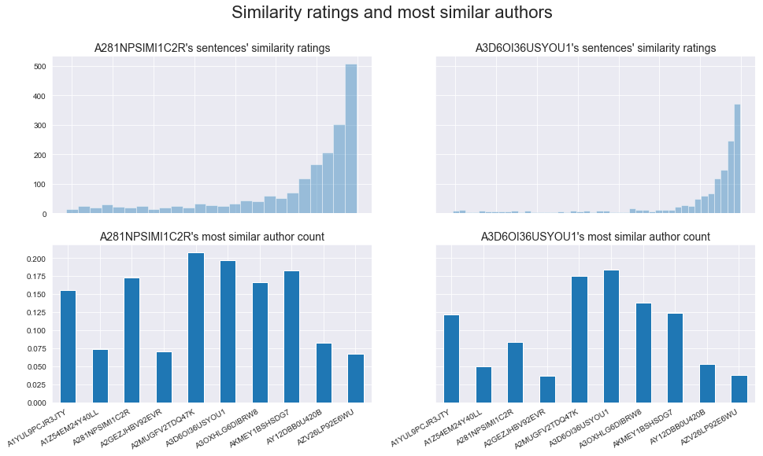

```python
fig, ((ax3, ax4), (ax1, ax2)) = plt.subplots(2, 2, sharey='row', sharex='row', figsize=(16,9))
fig.suptitle('Similarity ratings and most similar authors', size=22)
(sim_df.A281NPSIMI1C2R / sim_df.All).plot(kind='Bar', ax=ax1)
ax1.set_title("A281NPSIMI1C2R's most similar author count", size=14)
(sim_df.A3D6OI36USYOU1 / sim_df.All).plot(kind='Bar', ax=ax2)
ax2.set_title("A3D6OI36USYOU1's most similar author count", size=14)
sns.distplot(vals_A281NPSIMI1C2R, ax=ax3, kde=False)
ax3.set_title("A281NPSIMI1C2R's sentences' similarity ratings", size=14)
sns.distplot(vals_A3D6OI36USYOU1, ax=ax4, kde=False)
ax4.set_title("A3D6OI36USYOU1's sentences' similarity ratings", size=14)
fig.autofmt_xdate()
plt.show()
```

### Counts of most similar authors

The second row of histograms shows us the counts of the most similar author across sentences from two authors: A281NPSIMI1C2R on the left and A3D6OI36USYOU1 on the right. The counts are represented as proportions because of our present class imbalances. These two authors were selected as they were high on the similar lists *and not over or under represented*. Interestingly enough, the dissimilar authors are consistent as well.

## Vectorizing with tf-idf, clustering, and visualizing

The next few cells run the term frequency-inverse document frequency vectorizer from sklearn on the data set text. With the TFIDF features created for the text, we run latent semantic analysis with a reduction to 250 features. These features are then pushed through different unsupervised methods - kmeans, minibatchkmeans, meanshift, spectralclustering. The vectors are flattened with an LSA of two and standard scaling to visualize.

```python
for i, text in zip(df.index, df.Text):
    df.loc[i]['Text'] = cleaner(text)
df.drop(labels=['Id', 'ProfileName', 'Time'], axis=1, inplace=True)
df.head(1)
```

[output not shown]

```python
# First create tf-idf vectors
tv = TfidfVectorizer(ngram_range=(1,2), min_df=2, max_df=2000, stop_words='english')
tv_fit = tv.fit_transform(df['Text'])

# Setup X and y with feature values and names
for feature in tv.get_feature_names():
    df[feature] = 0

for i, j in zip(*tv_fit.nonzero()):
    df.loc[df.index[i], tv.get_feature_names()[j]] = tv_fit[i, j]

# pickle for use to avoid long computation in prior cell
# with open('df', 'wb') as file:
#     pickle.dump(df, file)

# with open('df', 'rb') as file:
#     my_df = pickle.load(file)

X = df.drop(['ProductId', 'UserId', 'HelpfulnessNumerator', 'HelpfulnessDenominator', 'Score', 'Summary', 'Text'], axis=1)
y = df['UserId']
```

```python
# Dimension reduction via LSA
svd = TruncatedSVD(250)
LSA = make_pipeline(svd, Normalizer(norm='l2', copy=False))
X_LSA = LSA.fit_transform(X)

# Initiate unsupervised clusters
mini_k = MiniBatchKMeans(n_clusters=10)
spec = SpectralClustering(n_clusters=10)
bw = estimate_bandwidth(X, quantile=0.66)
ms = MeanShift(bandwidth=bw)
mini_k.fit(X_LSA)
spec.fit(X_LSA)
ms.fit(X_LSA)
pred_mini_k = mini_k.predict(X_LSA)
pred_spec = spec.labels_
pred_ms = ms.labels_

# Dilute to two dimensions for graphing and add each label as a feature
dim_red = make_pipeline(TruncatedSVD(2), StandardScaler()).fit_transform(X)
new_df = pd.DataFrame(dim_red, columns=['one', 'two'], index=y.index)
new_df['pred_mini_k'] = pred_mini_k
new_df['pred_spec'] = pred_spec
new_df['pred_ms'] = pred_ms
new_df['actual'] = y
new_df.head()
```

|  | one | two | pred_mini_k | pred_spec | pred_ms | actual |
| --- | --- | --- | --- | --- | --- | --- |
| 93772 | -0.143722 | -0.643267 | 4 | 3 | 0 | AY12DBB0U420B |
| 371933 | -0.010274 | -0.177032 | 4 | 3 | 0 | AY12DBB0U420B |
| 491491 | 0.147927 | -0.764753 | 4 | 3 | 0 | AY12DBB0U420B |
| 553210 | -0.102879 | -0.370919 | 4 | 3 | 0 | AY12DBB0U420B |
| 278457 | 0.091936 | -0.295679 | 4 | 3 | 0 | AY12DBB0U420B |

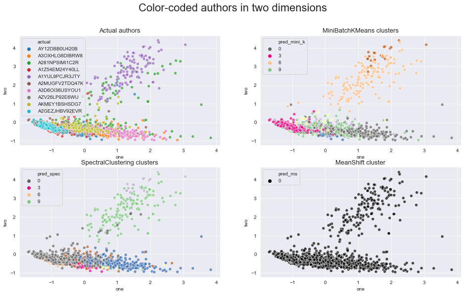

```python
fig, ((ax1, ax2), (ax3, ax4)) = plt.subplots(2, 2, tight_layout=False, figsize=(16,9))
fig.suptitle('Color-coded authors in two dimensions', size=22)
sns.scatterplot(x=new_df['one'], y=new_df['two'], hue=new_df['actual'], alpha=0.7, ax=ax1)
ax1.set_title('Actual authors', size=13)
sns.scatterplot(x=new_df['one'], y=new_df['two'], hue=new_df['pred_mini_k'], alpha=0.7, ax=ax2, palette='Accent_r')
ax2.set_title('MiniBatchKMeans clusters', size=13)
sns.scatterplot(x=new_df['one'], y=new_df['two'], hue=new_df['pred_spec'], alpha=0.7, ax=ax3, palette='Accent_r')
ax3.set_title('SpectralClustering clusters', size=13)
sns.scatterplot(x=new_df['one'], y=new_df['two'], hue=new_df['pred_ms'], alpha=0.7, ax=ax4, palette='cubehelix')
ax4.set_title('MeanShift cluster', size=13)
plt.show()
```

### Clearly colored clusters

##### Regarding all color-coded cluster graphs: It is critical to note that colors can not be cross referenced from one graph to another. Even with the same lines of code to graph, different colors can be produced as the labels are ultimately abstract and are only to differentiate.

It appears the sentence colonies capture the gist of actual clusters in the minibatch and spectral clustering approaches. The clustering via colors seems consistent and clear; visually it seems to share some common ground with the actual groups. The bottom mass has at least three major authors - although this looks more accurate via minibatch. The thinner spread to the northeast is hard to quantify, but it is consistent with the actuals in that it is not homogenous nor linearly separable. This dimension-reduction technique didn't quite separate the groups for us so nicely - more on that later.

## KMeans clusters

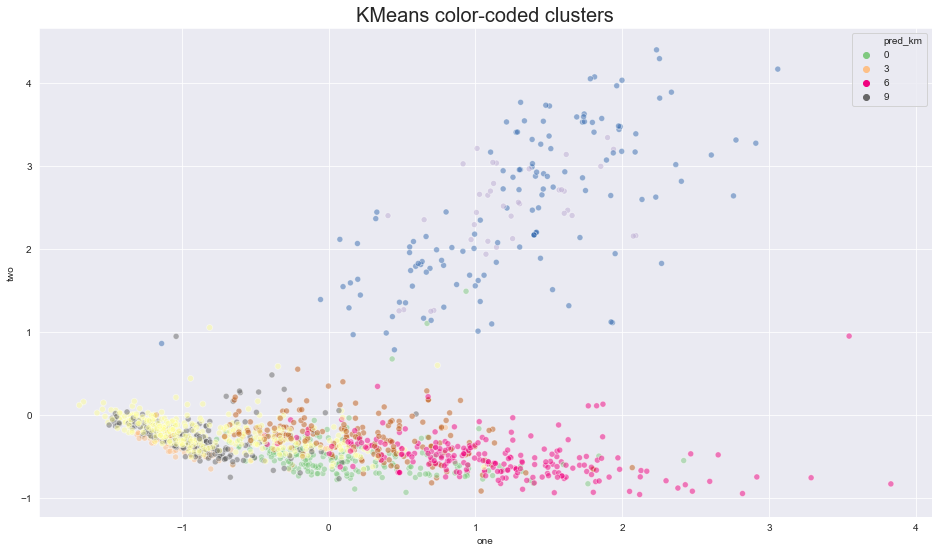

```python
kmeans = KMeans(n_clusters=10, n_init=20, max_iter=400)
kmeans.fit(X_LSA)
pred_km = kmeans.predict(X_LSA)
new_df['pred_km'] = pred_km

fig, ax = plt.subplots(figsize=(16,9))
sns.scatterplot(x=new_df['one'], y=new_df['two'], hue=new_df['pred_km'], palette='Accent', alpha=0.5)
ax.set_title('KMeans color-coded clusters', size=20)
plt.show()
```

## KMeans and transparent points

Above we have a KMeans visualization. This seems to have done a very nice job of visually matching the bottom blob. Once again it is difficult to quantify the accuracy of the northeast spread, but it appears to perform better. Transparency has been added to aid in overlapping markers.

## Improved visualization

As promised, let's attempt to improve author separation. TSNE is known to perform well on dimension-reduction visualization. Our final visualization below uses KMeans once again with this technique. It is placed beside actual labels to show the trends.

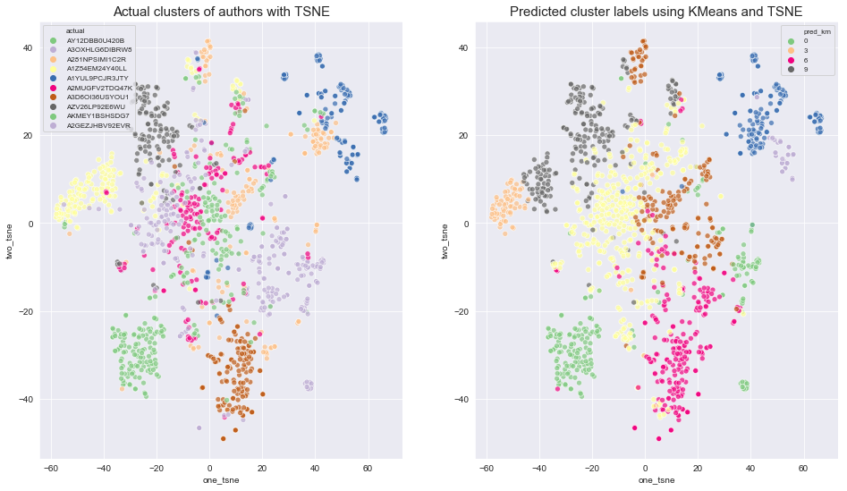

```python
svd_tsne = TruncatedSVD(50)
tsne = TSNE()
dim_red_tsne = make_pipeline(svd_tsne, tsne).fit_transform(X)

new_df['one_tsne'] = dim_red_tsne[:,0]
new_df['two_tsne'] = dim_red_tsne[:,1]

fig, (ax1, ax2) = plt.subplots(1, 2, figsize=(16,9))
sns.scatterplot(x=new_df['one_tsne'], y=new_df['two_tsne'], hue=new_df['actual'], palette='Accent', alpha=0.7, ax=ax1)
ax1.set_title('Actual clusters of authors with TSNE', size=15)
ax1.legend(fontsize='8')
sns.scatterplot(x=new_df['one_tsne'], y=new_df['two_tsne'], hue=new_df['pred_km'], palette='Accent', alpha=0.7, ax=ax2)
ax2.set_title('Predicted cluster labels using KMeans and TSNE', size=15)
ax2.legend(fontsize='8')
plt.show()
```

## KMeans does better than initially thought

With the TSNE trick to visualize the outcomes, we can see that KMeans might actually be doing a *very* good job of clustering and identifying authors' differences based on sentence embedding. Other than the westernmost bicluster and an amibitiously large center mass, the algorithm is nearly spot on in separating authors. It's even detecting some outlier behaviors, such as the dots south of the northernmost island. Very cool!

## Further work

#### What would make significant improvements?

In the end, I am fairly happy with the outcomes of the model. Further work tuning some unsupervised hyperparameters and advanced feature engineering would likely make this model truly shine. The only other thing missing is a concrete metric to measure the KMeans clustering labels versus the actual values. The scipy or statsmodels libraries will probably handle this with ease. Based on what I know, I might try one-way ANOVA tests or determine z-scores to quantify model accuracies and shortfalls. Also - it would be nice to get that pesky MeanShift model to work.